# Lab 5

- Show All Code
- Hide All Code
- View Source

Author

Adam Kong

## Revision Reflection

This reflection won’t be as long since there were not too many errors in this lab. One of the first errors I made in this lab were some stylistic choices such as keeping redundant information. This included information on the x-axis being in the title. Or information on the y-axis being in the legend. In the first steps, I didn’t correct much but included more information about where this information came from and what information is actually being presented on the graph. I fixed what was on the plots and less of what was going on to create those plots.

In the time series section I made two significant changes, first I changed fct_reorder to fct_reorder2. After looking up in the help files, it’s clear that fct_reorder is made for 1-D and fct_reorder2 is intended for 2-D, which this graph is. The second change I made was to change the axis-labels to indicate the weight was in grams. I didn’t indicate that at first but then I made this correction. Also changed the title around and fixed some axis.

I made the most amount of changes in Weekly Captures. I found that I made most of my code more complicated than before. but using several other functions and ideas from the past weeks, I realized my code could be much simpler and easier to read instead. Here I also changed the axis labels on the plots, removing redundant information and making it easier to read. In step 1 I shortened my data, making it much more simpler to read and keeping the dates shorts into one data set instead. For step 2 in Weekly Captures I use dplyr and change the orders of the function before I plot my data. In the original submission I changed the functions in the ggplot code, but after seeing Professor Theobold’s comment I thought of how much easier it would be to read to have it separated instead. Lastly I used dplyr mutate to change my data rather than use the $ to get into a data set I was already in. This error was likely because of the select function at the end but I readjusted my code to make more sense and more straightforward. Another note I do want to say is Professor Theobold says for step 2 to use one dplyr function and two forcat functions. I used only one dplyr function and one forcat function to change the order.

## **1. Revisiting Lab 2**

```r
library(tidyverse)
library(forcats)
library(lubridate)
```

Import Data from Lab 2:

```r
# Code for question 1!
surveys <- read_csv(here::here("Week 2", "Lab 2", "surveys.csv"))
```

Graph Import

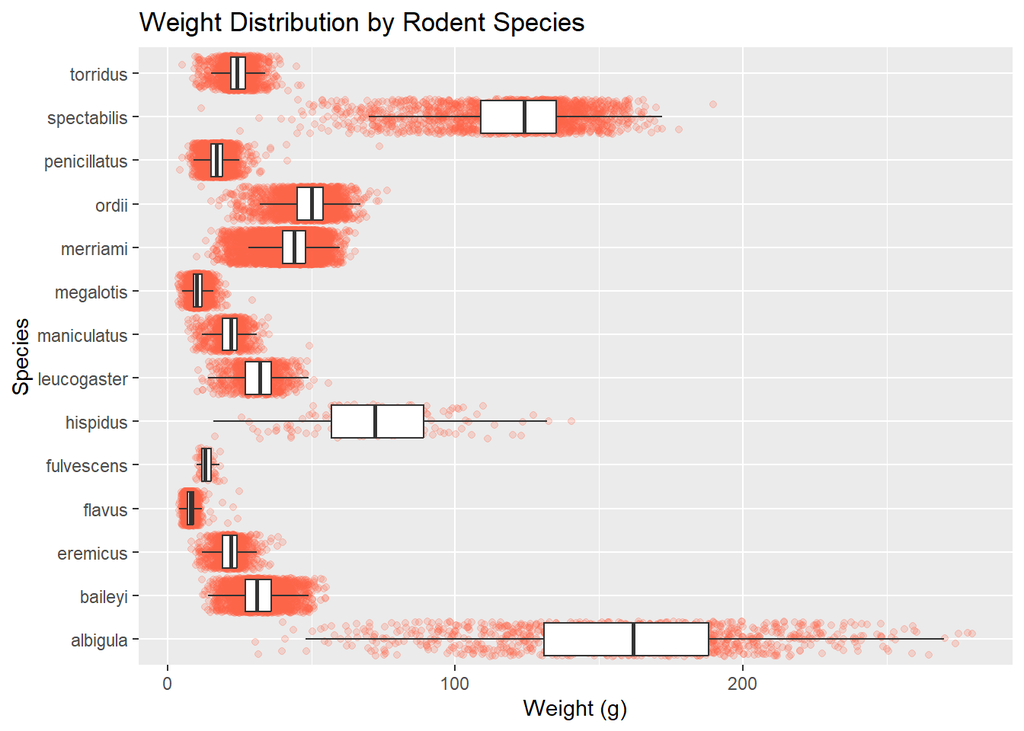

```r
# Code for question 8 (and 9 and 10 and 11 and 12)! :)
ggplot(data = surveys, aes(x = weight, y = species)) +
  geom_jitter(color = "tomato", alpha = 0.2) +
  geom_boxplot(outlier.shape = NA) +
  labs(
    title = "Weight Distribution by Rodent Species",
    x = "Weight (g)",
    y = "Species")
```

**1. Reorder the species so the boxplots for weights go in descending order (largest to smallest).**

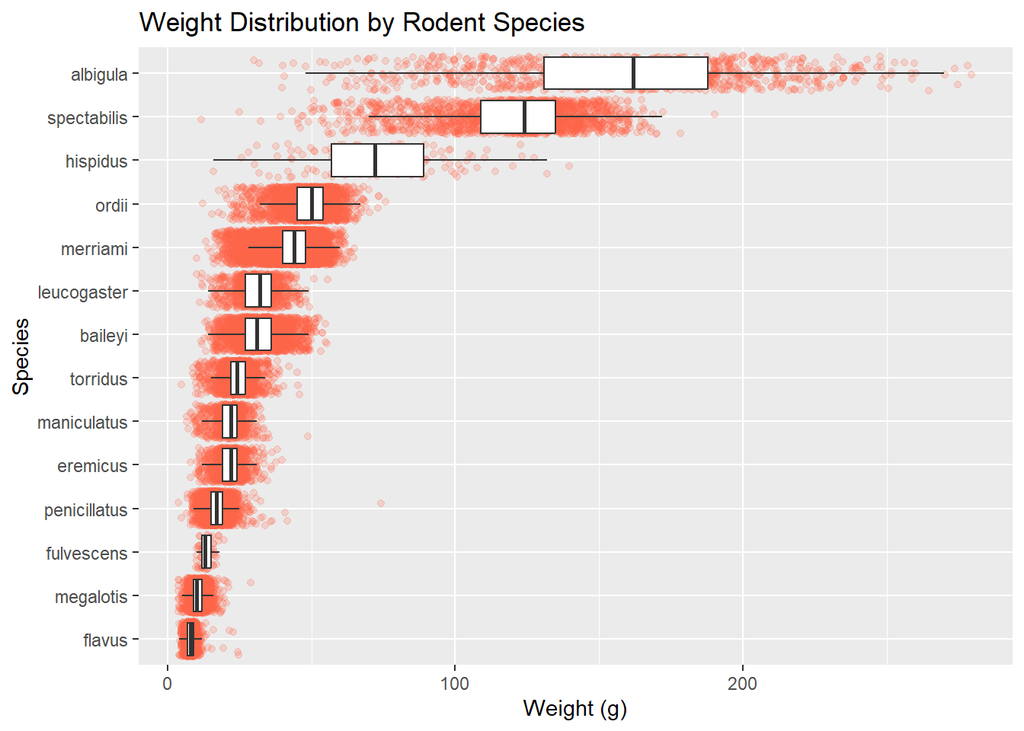

```r
ggplot(data = surveys,
       mapping = aes(weight, fct_reorder(species, weight))) +
  geom_jitter(color = "tomato", alpha = 0.2) +
  geom_boxplot(outlier.shape = NA) +
  labs(
    title = "Weight Distribution by Rodent Species",
    x = "Weight (g)",
    y = "Species"
  )
```

**2. Now that you’ve reordered, look at your y-axis label. That’s long! Let’s take Will Chase’s advice and move the y-axis label to the top of the plot.**

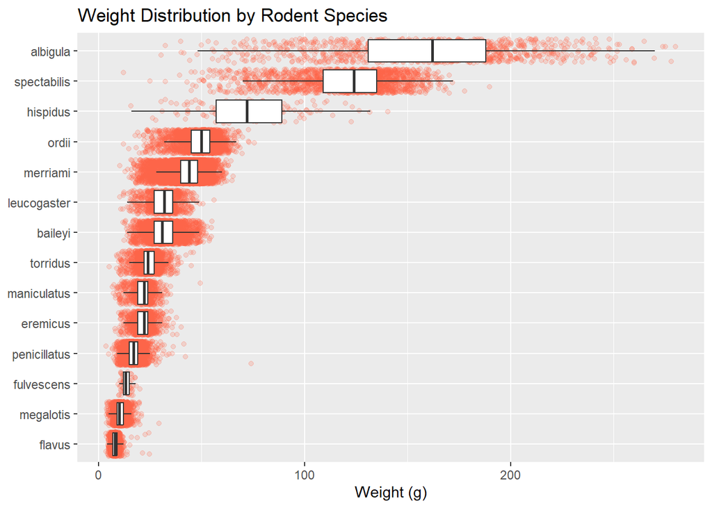

```r
ggplot(data = surveys,
       mapping = aes(weight, fct_reorder(species, weight))) +
  geom_jitter(color = "tomato", alpha = 0.2) +
  geom_boxplot(outlier.shape = NA) +
  labs(
    title = "Weight Distribution by Rodent Species",
    x = "Weight (g)"
  ) +
  theme(
    axis.title.y = element_blank()
  )
```

## **2. Time-Series Plot**

**1. Create a visualization how weights vary for each genus over the duration of the study.**

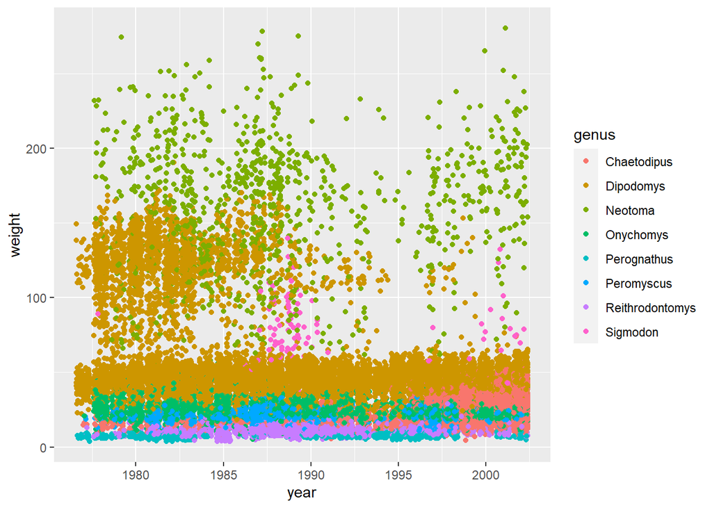

```r
ggplot(data = surveys, mapping = aes(x = year, y = weight, color = genus)) +
  geom_jitter()
```

**2. Calculate and plot the mean weight for each genus for each year.**

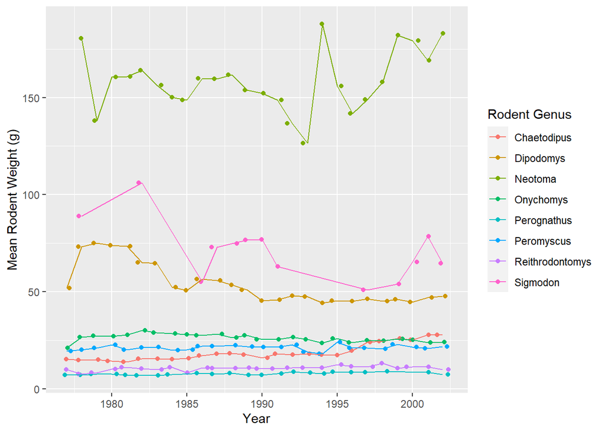

```r
mean_surveys <- surveys |>
  group_by(year, genus) |>
  summarise(mean_weight = mean(weight))

ggplot(data = mean_surveys, mapping = aes(x = year,
                                          y = mean_weight,
                                          color = genus)) +
  geom_jitter() +
  geom_line() +
  labs(
    x = "Year",
    y = "Mean Rodent Weight (g)",
    color = "Rodent Genus"
  )
```

**3. Reorder the lines so the mean weights go in descending order (largest to smallest).**

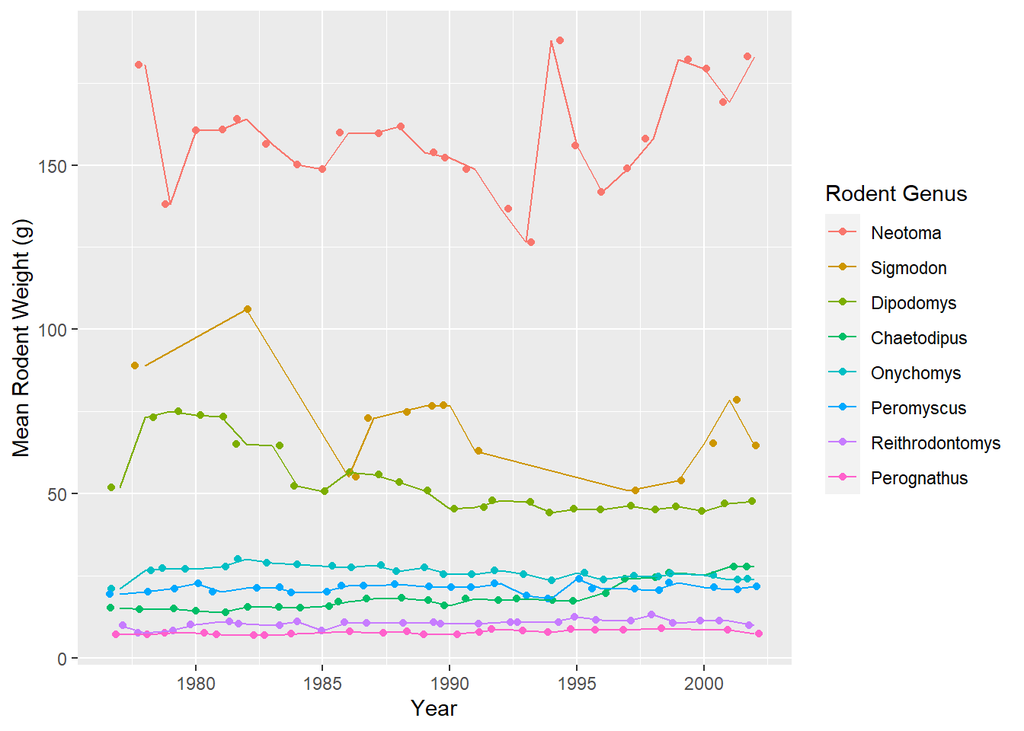

```r
ggplot(data = mean_surveys,
       mapping = aes(x = year,
                     y = mean_weight,
                     color = fct_reorder2(genus,
                                          .x = year,
                                          .y = mean_weight,
                                          .desc = TRUE))) +
  geom_jitter() +
  geom_line() +
  labs(
    x = "Year",
    y = "Mean Rodent Weight (g)",
    color = "Rodent Genus"
  )
```

```r
# https://www.datanovia.com/en/blog/how-to-change-ggplot-legend-order/
```

**4. Now that you’ve reordered the lines, look at your legend’s label. That’s terrible! Let’s give the legend a new title *and* move the information from the y-axis to the plot title.**

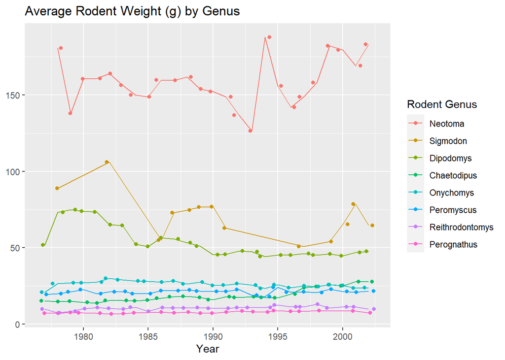

```r
ggplot(data = mean_surveys,
       mapping = aes(x = year,
                     y = mean_weight,
                     color = fct_reorder2(genus,
                                          .x = year,
                                          .y = mean_weight,
                                          .desc = TRUE))) +
  geom_jitter() +
  geom_line() +
  labs(
    title = "Average Rodent Weight (g) by Genus",
    x = "Year",
    color = "Rodent Genus"
  ) +
  theme(
    axis.title.y = element_blank()
  )
```

## **3. Captures Over the Week**

**1. Create a visualization of the number of rodents captured each day of the week.**

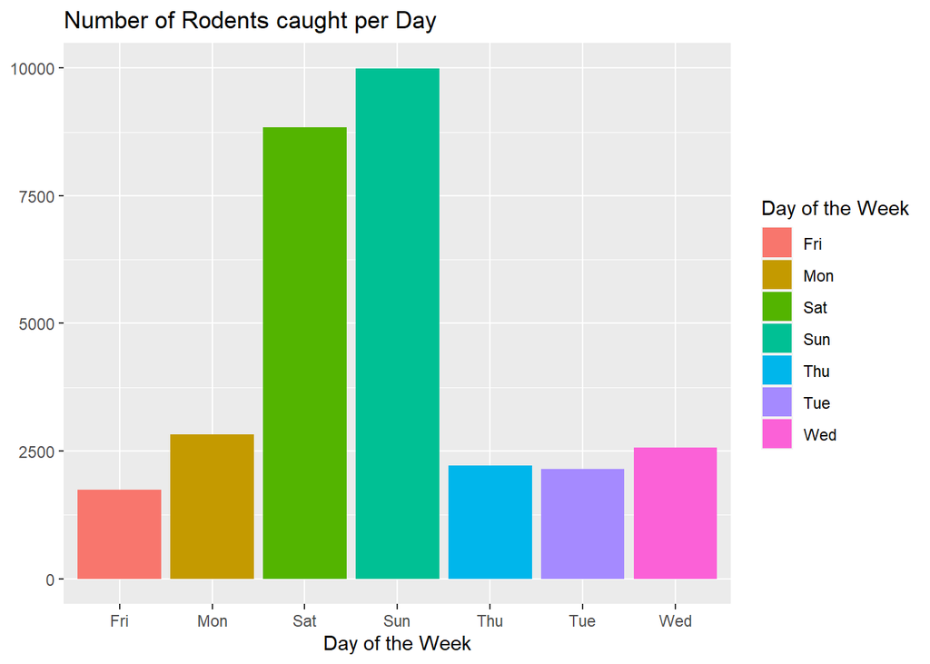

```r
surveys_date <- surveys |>
  group_by(day_of_week) |>
  count(day_of_week)

ggplot(data = na.omit(surveys_date),
       mapping = aes(x = day_of_week,
                     y = n,
                     fill = day_of_week)) +
  geom_col() +
  labs(
    title = "Number of Rodents caught per Day",
    x = "Day of the Week",
    fill = "Day of the Week"
  ) +
  theme(
    axis.title.y = element_blank()
  )
```

**2. Change the order of the day of the week to go Monday through Sunday.**

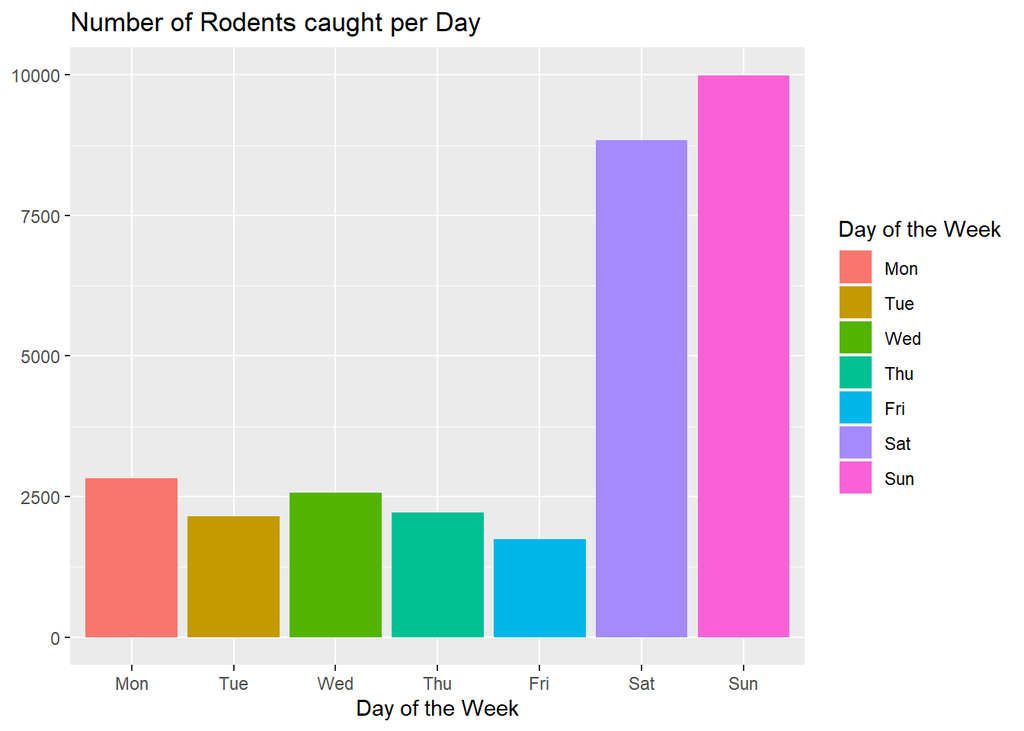

```r
days_in_order <- c("Mon", "Tue", "Wed", "Thu", "Fri", "Sat", "Sun")

week_day <- surveys_date |>
  mutate(day_of_week = fct(day_of_week, days_in_order))

ggplot(data = na.omit(week_day),
       mapping = aes(x = day_of_week,
                     y = n,
                     fill = day_of_week)) +
  geom_col() +
  labs(
    title = "Number of Rodents caught per Day",
    x = "Day of the Week",
    fill = "Day of the Week"
  ) +
  theme(
    axis.title.y = element_blank()
  )
```

**3. Collapse Monday through Friday into a `"Weekday"` level, and collapse Saturday and Sunday into a `"Weekend"` level. Plot the number of rodents captured between the two groups.**

```r
dates_collapsed <- surveys_date|>
  mutate(level = fct_collapse(day_of_week,
                              Weekday = c("Mon",
                                          "Tue",
                                          "Wed",
                                          "Thu",
                                          "Fri"),
                              Weekend = c("Sat",
                                          "Sun")))

# https://stackoverflow.com/questions/56533740/how-to-save-collapsed-factor-levels-for-multiple-variables-into-new-dataframe
# Thank you StackOverflow!

dates_collapsed |>
  group_by(level) |>
  summarise(sum_level = sum(n))
```

```
# A tibble: 3 × 2
  level   sum_level
  <fct>       <int>
1 Weekday     11511
2 Weekend     18827
3 <NA>          125
```

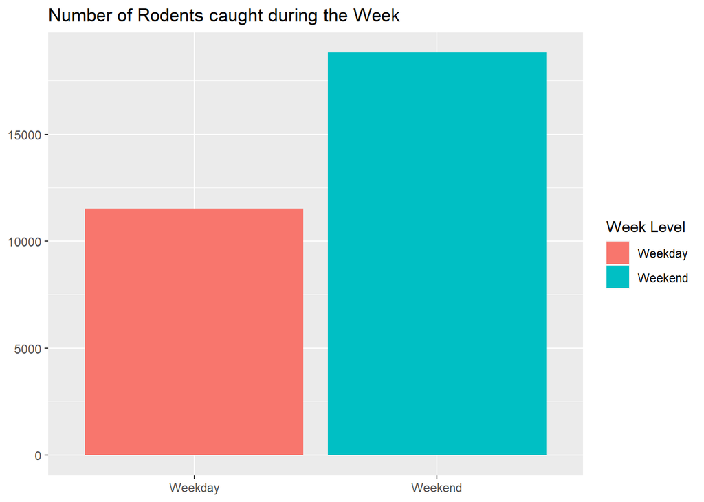

```r
# Total number of rodents caught on weekdays and weekends

ggplot(data = na.omit(dates_collapsed),
       mapping = aes(x = level,
                     y = n,
                     fill = level )) +
  geom_col() +
  labs(
    title = "Number of Rodents caught during the Week",
    fill = "Week Level"
  ) +
  theme(
    axis.title.x = element_blank(),
    axis.title.y = element_blank()
  )
```

# Extra Findings

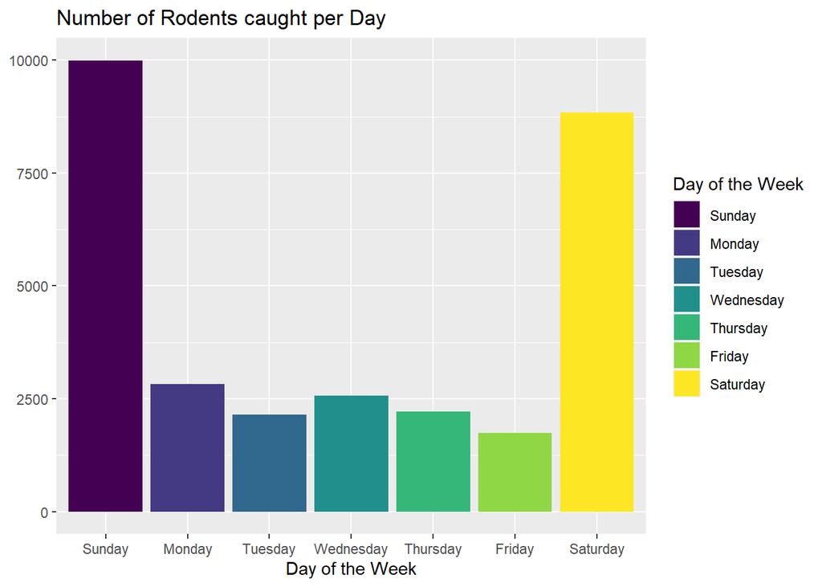

```r
new_dates2 <- surveys |>
  select(date) |>
  mutate(change_date = wday(date, label=TRUE, abbr=FALSE)) |>
  group_by(change_date) |>
  count(change_date)

ggplot(data = na.omit(new_dates2),
       mapping = aes(x = change_date,
                     y = n,
                     fill = change_date)) +
  geom_col() +
  labs(
    title = "Number of Rodents caught per Day",
    x = "Day of the Week",
    fill = "Day of the Week"
  ) +
  theme(
    axis.title.y = element_blank()
  )
```

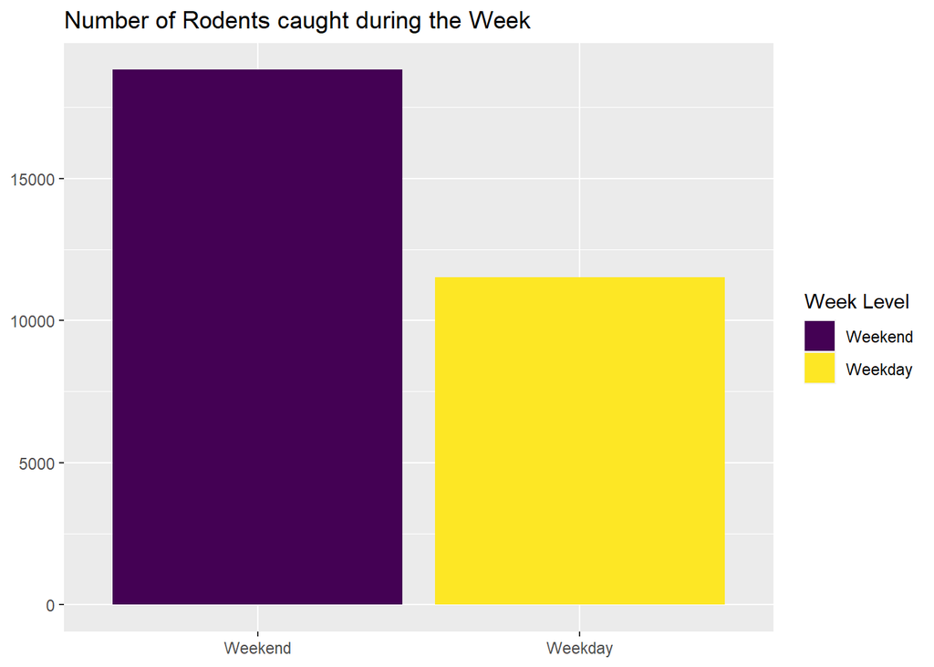

```r
dates_collapsed2 <- new_dates2|>
  mutate(level = fct_collapse(change_date,
                              Weekday = c("Monday",
                                          "Tuesday",
                                          "Wednesday",
                                          "Thursday",
                                          "Friday"),
                              Weekend = c("Saturday",
                                          "Sunday")))

# https://stackoverflow.com/questions/56533740/how-to-save-collapsed-factor-levels-for-multiple-variables-into-new-dataframe

ggplot(data = na.omit(dates_collapsed2),
       mapping = aes(x = level,
                     y = n,
                     fill = level )) +
  geom_col() +
  labs(
    title = "Number of Rodents caught during the Week",
    fill = "Week Level"
  ) +
  theme(
    axis.title.x = element_blank(),
    axis.title.y = element_blank()
  )
```